# Eleigant Graphics with R, Part 1

## 3. Histogram

> Histogram differes from barplot in one important issue. REMEMBER, histogram always summarize counts on Y axis

Lets load CO2 dataset in the base plot

```r
head(CO2)
```

```
##   Plant   Type  Treatment conc uptake
## 1   Qn1 Quebec nonchilled   95   16.0
## 2   Qn1 Quebec nonchilled  175   30.4
## 3   Qn1 Quebec nonchilled  250   34.8
## 4   Qn1 Quebec nonchilled  350   37.2
## 5   Qn1 Quebec nonchilled  500   35.3
## 6   Qn1 Quebec nonchilled  675   39.2
```

Lets check it more precisely use str() and summary() functions

```r
str(CO2)
```

```
## Classes 'nfnGroupedData', 'nfGroupedData', 'groupedData' and 'data.frame':   84 obs. of  5 variables:
##  $ Plant    : Ord.factor w/ 12 levels "Qn1"<"Qn2"<"Qn3"<..: 1 1 1 1 1 1 1 2 2 2 ...
##  $ Type     : Factor w/ 2 levels "Quebec","Mississippi": 1 1 1 1 1 1 1 1 1 1 ...
##  $ Treatment: Factor w/ 2 levels "nonchilled","chilled": 1 1 1 1 1 1 1 1 1 1 ...
##  $ conc     : num  95 175 250 350 500 675 1000 95 175 250 ...
##  $ uptake   : num  16 30.4 34.8 37.2 35.3 39.2 39.7 13.6 27.3 37.1 ...
##  - attr(*, "formula")=Class 'formula'  language uptake ~ conc | Plant
##   .. ..- attr(*, ".Environment")=<environment: R_EmptyEnv>
##  - attr(*, "outer")=Class 'formula'  language ~Treatment * Type
##   .. ..- attr(*, ".Environment")=<environment: R_EmptyEnv>
##  - attr(*, "labels")=List of 2
##   ..$ x: chr "Ambient carbon dioxide concentration"
##   ..$ y: chr "CO2 uptake rate"
##  - attr(*, "units")=List of 2
##   ..$ x: chr "(uL/L)"
##   ..$ y: chr "(umol/m^2 s)"
```

```r
summary(CO2)
```

```
##      Plant             Type         Treatment       conc          uptake
##  Qn1    : 7   Quebec     :42   nonchilled:42   Min.   :  95   Min.   : 7.70
##  Qn2    : 7   Mississippi:42   chilled   :42   1st Qu.: 175   1st Qu.:17.90
##  Qn3    : 7                                    Median : 350   Median :28.30
##  Qc1    : 7                                    Mean   : 435   Mean   :27.21
##  Qc3    : 7                                    3rd Qu.: 675   3rd Qu.:37.12
##  Qc2    : 7                                    Max.   :1000   Max.   :45.50
##  (Other):42
```

Lets draw a histogram for y axis

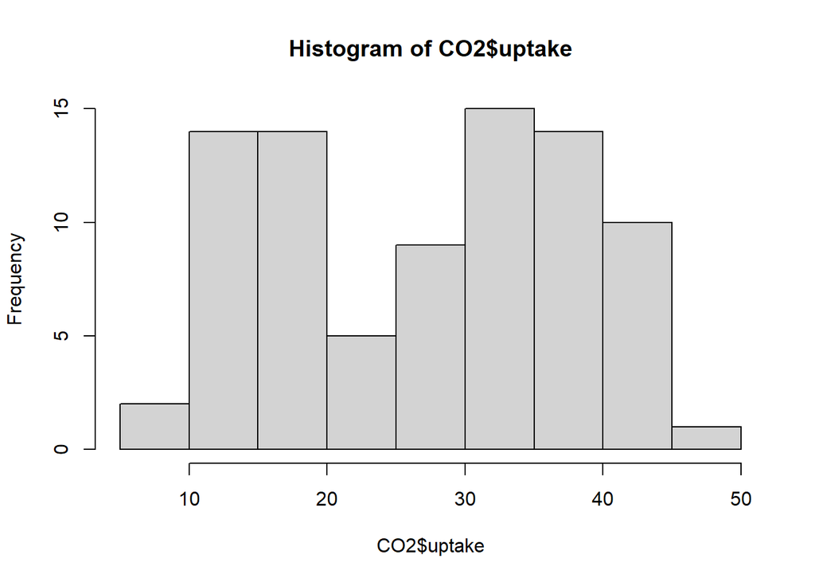

```r
hist(CO2$uptake) # y axis is alway frequency
```

When drawing a histogram , u need to think about the number of bins to show your data.

Lets compare same graphs with different bins

```r
par(mfrow=c(2,2))
hist(CO2$uptake)
hist(CO2$uptake,breaks=3,col="red")
hist(CO2$uptake,breaks=5,col="blue")
hist(CO2$uptake,breaks=7,col="gold")
```

You should get this graph

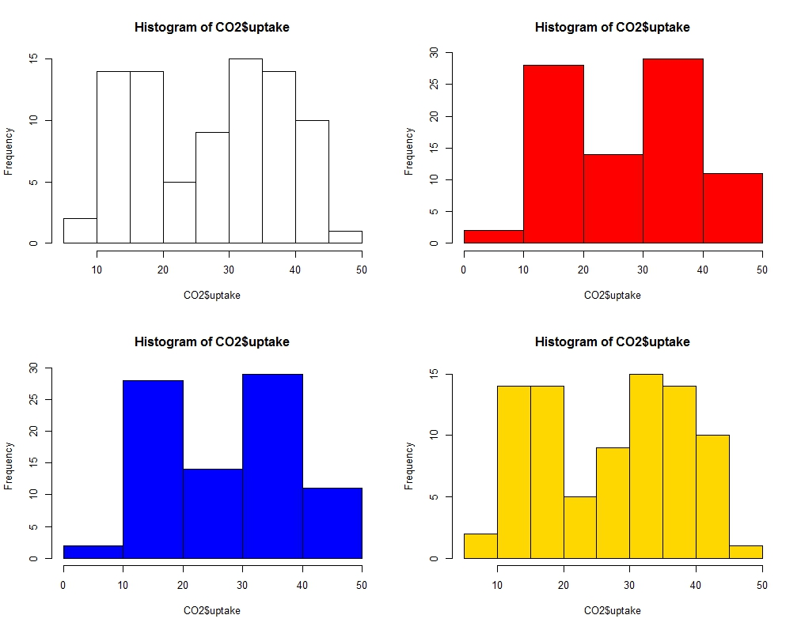

my graph

**R chooses how to bin your data for you by default using an algorithm, but if you want coarser or finer groups, you need to define it manually as earlier.**

Some tweaks

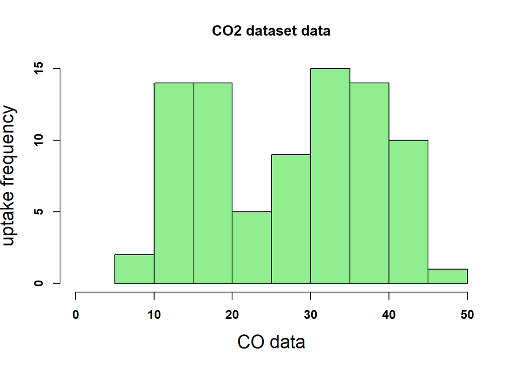

```r
hist(CO2$uptake, freq=TRUE, xlab="CO data",ylab="uptake frequency", main="CO2 dataset data", col="lightgreen", breaks=9, xlim=c(0,50),pch=16,cex=1.5,cex.lab=1.5,font=2)
```